## 1. INTRODUCTION

### 1.1. Aim of the Project

In this project, it is aimed to model liquor demand in Virginia and North Carolina. The original study has been conducted by Mark L. Burkey. With his research, it was aimed to find answer whether the geographical restrictions on the alcohol make any effect on the alcohol-related problems. He focused arrastments because of driving under the influence of alcohol (other drugs) and tried to explain how alcohol restriction affect the DUI arrastments. The results have shown that alcohol restrictions did not make any effect on arrastments. In our project, we tried to find the answer to a different problem which is domestic violence in households. Our research question is how geographical alcohol restrictions affect the domestic violance. We constructed both traditional regression model with OLS (benchmark model) and also spatial models.

### 1.2. Information About Data Set

In this project, the data set contains 49 variables. The year of the data set is 2003. The variables give information about geographical features of states as well as demographic features. After importing data set, first we need to know the class of the data set. With `class()` function, we can say that the data set is *“SpatialPolygonsDataFrame”*. We can see the head of the data set in below table:

Head of the Data Set

|  | GEO_ID | STATE | COUNTY | NAME | LSAD | CENSUSAREA | FIPS2 | Lon | Lat | FIPS | qtystores | SALESPC | PCI | COMM15OVP | COLLENRP | SOMECOLLP | ARMEDP | NONWHITEP | UNEMPP | ENTRECP | PUBASSTP | POVPOPP | URBANP | FOREIGNBP | BAPTISTSP | ADHERENTSP | BKGRTOMIX | COUNTMXBV | MXBVSQM | … |
| --- | --- | --- | --- | --- | --- | --- | --- | --- | --- | --- | --- | --- | --- | --- | --- | --- | --- | --- | --- | --- | --- | --- | --- | --- | --- | --- | --- | --- | --- | --- |
| 0 | 0500000US37179 | 37 | 179 | Union | County | 631.52 | 37179 | -80.53 | 35.07 | 37179 | 2 | 39.30 | 21966 | 37.45 | 3.29 | 31.52 | 0.01 | 17.21 | 4.30 | 5.38 | 1.65 | 8.14 | 50.17 | 3.90 | 21.48 | 47.67 | 3.71 | 32 | 0.05 | … |
| 1 | 0500000US37181 | 37 | 181 | Vance | County | 253.52 | 37181 | -78.42 | 36.34 | 37181 | 2 | 76.83 | 15884 | 25.17 | 2.92 | 21.54 | 0.03 | 51.63 | 8.29 | 4.91 | 5.25 | 20.50 | 49.17 | 2.40 | 15.20 | 45.69 | 2.83 | 9 | 0.04 | … |
| 2 | 0500000US37191 | 37 | 191 | Wayne | County | 553.09 | 37191 | -78.03 | 35.32 | 37191 | 6 | 54.34 | 16999 | 27.03 | 4.18 | 28.74 | 3.08 | 38.66 | 5.88 | 5.32 | 2.89 | 13.84 | 55.16 | 2.38 | 6.86 | 37.27 | 3.13 | 25 | 0.05 | … |
| 3 | 0500000US37001 | 37 | 001 | Alamance | County | 423.94 | 37001 | -79.38 | 36.01 | 37001 | 5 | 50.09 | 19429 | 30.86 | 5.08 | 30.05 | 0.01 | 24.70 | 5.09 | 6.00 | 1.54 | 11.14 | 69.28 | 4.47 | 10.47 | 42.30 | 2.58 | 42 | 0.10 | … |
| 4 | 0500000US37003 | 37 | 003 | Alexander | County | 259.99 | 37003 | -81.19 | 35.92 | 37003 | 1 | 30.53 | 18515 | 35.91 | 2.73 | 22.41 | 0.05 | 7.94 | 2.50 | 4.67 | 2.75 | 8.48 | 17.24 | 1.51 | 35.14 | 65.56 | 8.14 | 0 | 0.00 | … |
| 5 | 0500000US37005 | 37 | 005 | Alleghany | County | 235.06 | 37005 | -81.12 | 36.44 | 37005 | 1 | 76.43 | 17707 | 27.20 | 3.03 | 26.58 | 0.00 | 5.44 | 4.60 | 6.42 | 2.56 | 17.15 | 0.00 | 3.39 | 12.78 | 27.82 | 15.71 | 0 | 0.00 | … |

Before going deep in the data set, the variables and their descriptions are also important to understand and conduct the analysis. Some variables are clear and easy to understand, but some variables are hard to interpret and we need to understand them. Therefore, all variables and necessary descriptions of the variables are provided below:

All Variables:

```
##  [1] "GEO_ID"     "STATE"      "COUNTY"     "NAME"       "LSAD"
##  [6] "CENSUSAREA" "FIPS2"      "Lon"        "Lat"        "FIPS"
## [11] "qtystores"  "SALESPC"    "PCI"        "COMM15OVP"  "COLLENRP"
## [16] "SOMECOLLP"  "ARMEDP"     "NONWHITEP"  "UNEMPP"     "ENTRECP"
## [21] "PUBASSTP"   "POVPOPP"    "URBANP"     "FOREIGNBP"  "BAPTISTSP"
## [26] "ADHERENTSP" "BKGRTOMIX"  "COUNTMXBV"  "MXBVSQM"    "BKGRTOABC"
## [31] "MXBVPPOP18" "DUI1802"    "FVPTHH02"   "DC"         "GA"
## [36] "KY"         "MD"         "SC"         "TN"         "WV"
## [41] "VA"         "AREALANDSQ" "COUNTBKGR"  "TOTALPOP"   "POP18OV"
## [46] "LABFORCE"   "HHOLDS"     "POP25OV"    "POP16OV"
```

Descriptions:

- **Lon & Lat:** Longitude and latitude of county centroid
- **FIPS, FIPS2:** Code for county (Federal Information Processing Standard)
- **qtystores:** Number of liquor stores in county
- **SALESPC:** Liquor Sales per capita per year, $
- **PCI:** Per capita income
- **COMM15OVP:** % of commuting over 15 minutes to work
- **COLLENRP:** % of people currently enrolled in college
- **SOMECOLLP:** % of people with “some college” or higher education level
- **ARMEDP:** % in armed forces
- **NONWHITEP:** % of nonwhite people
- **UNEMPP:** % of unemployed people
- **ENTRECP** % of employment in entertainment or recreation fields (proxy for tourism areas)
- **PUBASSTP:** % on public assistance of some sort
- **POVPOPP:** % in poverty
- **URBANP:** % of people living in urban areas
- **FOREIGNBP:** % foreign born
- **BAPTISTSP:** % of southern baptist (historically anti-alcohol)
- **ADHERENTSP:** % of adherents of any religion
- **BKGRTOMIX:** Weighted average distance from block group to nearest bar selling liquor
- **COUNTMXBV:** Count of bars selling liquor
- **MXBVSQM:** Bars per square mile
- **BKGRTOABC:** Distance for block group to nearest retail liquor outlet (“ABC stores”)
- **MXBVPPOP18:** Bars per 1,000 people 18 and older
- **DUI1802:** DUI arrests per 1,000 people 18+
- **FVPTHH02:** Offences against families and children (domestic violence) per 1,000 households
- **DC,GA, KY, MD, SC, TN, WV, VA:** Dummy variables for counties bordering other states
- **AREALANDSQ:** Area of county
- **COUNTBKGR:** Count of block groups in county
- **TOTALPOP:** Population of county
- **POP18OV:** Population of 18+ people in county
- **LABFORCE:** number of people in labor force in county
- **HHOLDS:** number of households in county
- **POP25OV:** Population of 25+ people in county
- **POP16OV:** Population of 16+ people in county

After having information about variables, we can see the summary of the data set.

```
## Object of class SpatialPolygonsDataFrame
## Coordinates:
##         min       max
## x -84.32187 -75.24227
## y  33.84452  39.46601
## Is projected: FALSE
## proj4string : [+proj=longlat +datum=NAD83 +no_defs]
## Data attributes:
##             GEO_ID    STATE        COUNTY            NAME         LSAD
##  0500000US37001:  1   37:100   001    :  2   Franklin  :  3   city  : 39
##  0500000US37003:  1   51:134   003    :  2   Richmond  :  3   County:195
##  0500000US37005:  1            005    :  2   Alleghany :  2
##  0500000US37007:  1            007    :  2   Bedford   :  2
##  0500000US37009:  1            009    :  2   Brunswick :  2
##  0500000US37011:  1            011    :  2   Cumberland:  2
##  (Other)       :228            (Other):222   (Other)   :220
##    CENSUSAREA          FIPS2          Lon              Lat             FIPS
##  Min.   :  1.999   37001  :  1   Min.   :-83.94   Min.   :34.16   37001  :  1
##  1st Qu.:234.037   37003  :  1   1st Qu.:-80.32   1st Qu.:35.82   37003  :  1
##  Median :381.377   37005  :  1   Median :-78.55   Median :36.75   37005  :  1
##  Mean   :376.530   37007  :  1   Mean   :-78.94   Mean   :36.74   37007  :  1
##  3rd Qu.:514.512   37009  :  1   3rd Qu.:-77.37   3rd Qu.:37.53   37009  :  1
##  Max.   :968.941   37011  :  1   Max.   :-75.63   Max.   :39.17   37011  :  1
##                    (Other):228                                    (Other):228
##    qtystores     SALESPC            PCI        COMM15OVP        COLLENRP
##  1      :80   Min.   :  0.00   14893  :  2   Min.   : 5.49   Min.   : 0.890
##  2      :49   1st Qu.: 38.00   12808  :  1   1st Qu.:25.89   1st Qu.: 2.663
##  0      :28   Median : 58.80   12830  :  1   Median :30.42   Median : 3.180
##  3      :22   Mean   : 64.98   13195  :  1   Mean   :30.52   Mean   : 4.576
##  5      :13   3rd Qu.: 78.74   13286  :  1   3rd Qu.:34.96   3rd Qu.: 4.180
##  4      :11   Max.   :297.70   13293  :  1   Max.   :48.79   Max.   :41.300
##  (Other):31                    (Other):227
##    SOMECOLLP         ARMEDP          NONWHITEP          UNEMPP
##  Min.   :16.55   Min.   : 0.0000   Min.   : 0.670   Min.   : 1.710
##  1st Qu.:23.38   1st Qu.: 0.0200   1st Qu.: 8.928   1st Qu.: 3.632
##  Median :27.15   Median : 0.0800   Median :22.170   Median : 4.670
##  Mean   :28.81   Mean   : 0.6656   Mean   :24.763   Mean   : 5.274
##  3rd Qu.:32.39   3rd Qu.: 0.2400   3rd Qu.:37.795   3rd Qu.: 6.452
##  Max.   :59.92   Max.   :21.5300   Max.   :81.590   Max.   :41.410
##
```

[output cut: 33 more lines]

```
##  0:220   0:219   0:100   Min.   :  1.986   12     : 10   13146  :  2
##  1: 14   1: 15   1:134   1st Qu.:235.451   10     :  8   100565 :  1
##                          Median :381.783   25     :  8   10290  :  1
##                          Mean   :377.358   11     :  7   10377  :  1
##                          3rd Qu.:518.925   14     :  7   10381  :  1
##                          Max.   :970.760   17     :  7   10516  :  1
##                                            (Other):187   (Other):227
##     POP18OV       LABFORCE       HHOLDS       POP25OV       POP16OV
##  10022  :  1   10134  :  1   2669   :  2   100128 :  1   10002  :  1
##  10042  :  1   10142  :  1   10029  :  1   10120  :  1   100501 :  1
##  10106  :  1   102470 :  1   10142  :  1   10403  :  1   10096  :  1
##  10179  :  1   10524  :  1   10186  :  1   107671 :  1   101238 :  1
##  10215  :  1   106066 :  1   10301  :  1   10803  :  1   101606 :  1
##  102361 :  1   10756  :  1   10394  :  1   10841  :  1   10207  :  1
##  (Other):228   (Other):228   (Other):227   (Other):228   (Other):228
```

From the summary of the data set, some variables like income and population are seen as in wrong format. So, we need to convert these variables into true format (factor to numeric).

```r
# converting factor variables to numeric variables

spadata$qtystores <- as.numeric(levels(spadata$qtystores))[spadata$qtystores]
spadata$PCI <- as.numeric(levels(spadata$PCI))[spadata$PCI]
spadata$COUNTMXBV <- as.numeric(levels(spadata$COUNTMXBV))[spadata$COUNTMXBV]
spadata$COUNTBKGR <- as.numeric(levels(spadata$COUNTBKGR))[spadata$COUNTBKGR]
spadata$TOTALPOP <- as.numeric(levels(spadata$TOTALPOP))[spadata$TOTALPOP]
spadata$POP18OV <- as.numeric(levels(spadata$POP18OV))[spadata$POP18OV]
spadata$LABFORCE <- as.numeric(levels(spadata$LABFORCE))[spadata$LABFORCE]
spadata$HHOLDS <- as.numeric(levels(spadata$HHOLDS))[spadata$HHOLDS]
spadata$POP25OV <- as.numeric(levels(spadata$POP25OV))[spadata$POP25OV]
spadata$POP16OV <- as.numeric(levels(spadata$POP16OV))[spadata$POP16OV]


# spadata$qtystores <- as.numeric(spadata$qtystores)
# spadata$PCI <- as.numeric(spadata$PCI)
# spadata$COUNTMXBV <- as.numeric(spadata$COUNTMXBV)
# spadata$COUNTBKGR <- as.numeric(spadata$COUNTBKGR)
# spadata$TOTALPOP <- as.numeric(spadata$TOTALPOP)
# spadata$POP18OV <- as.numeric(spadata$POP18OV)
# spadata$LABFORCE <- as.numeric(spadata$LABFORCE)
# spadata$HHOLDS <- as.numeric(spadata$HHOLDS)
# spadata$POP25OV <- as.numeric(spadata$POP25OV)
# spadata$POP16OV <- as.numeric(spadata$POP16OV)
```

Now, all the variables can be seen in the true formats in below table:

```
## 'data.frame':    234 obs. of  49 variables:
##  $ GEO_ID    : Factor w/ 234 levels "0500000US37001",..: 90 91 96 1 2 3 9 13 17 22 ...
##  $ STATE     : Factor w/ 2 levels "37","51": 1 1 1 1 1 1 1 1 1 1 ...
##  $ COUNTY    : Factor w/ 140 levels "001","003","005",..: 91 92 97 1 2 3 9 13 17 23 ...
##  $ NAME      : Factor w/ 212 levels "Accomack","Alamance",..: 194 195 201 2 4 6 19 29 36 47 ...
##  $ LSAD      : Factor w/ 2 levels "city","County": 2 2 2 2 2 2 2 2 2 2 ...
##  $ CENSUSAREA: num  632 254 553 424 260 ...
##  $ FIPS2     : Factor w/ 234 levels "37001","37003",..: 90 91 96 1 2 3 9 13 17 22 ...
##  $ Lon       : num  -80.5 -78.4 -78 -79.4 -81.2 ...
##  $ Lat       : num  35.1 36.3 35.3 36 35.9 ...
##  $ FIPS      : Factor w/ 234 levels "37001","37003",..: 90 91 96 1 2 3 9 13 17 22 ...
##  $ qtystores : num  2 2 6 5 1 1 1 5 4 0 ...
##  $ SALESPC   : num  39.3 76.8 54.3 50.1 30.5 ...
##  $ PCI       : num  21966 15884 16999 19429 18515 ...
##  $ COMM15OVP : num  37.5 25.2 27 30.9 35.9 ...
```

[output cut: 35 more lines]

After variable transformation, the data set is ready for analysis. In the following section, some explonatory data analysis (EDA) will be conducted in order to see the distribution of important factors in the data set.

### 1.3. Explonatory Data Analysis (EDA)

EDA is important tool to see the general picture of the data set. In this section, EDA has been applied as preliminary analysis. First analysis, obviously, to look at the dependent vairable in the model. Offences against families and children (domestic violence) per 1,000 households (FVPTHH02) is the dependent variable in the models for the following sections. The visualization of the domestic sales density in geographic map as below:

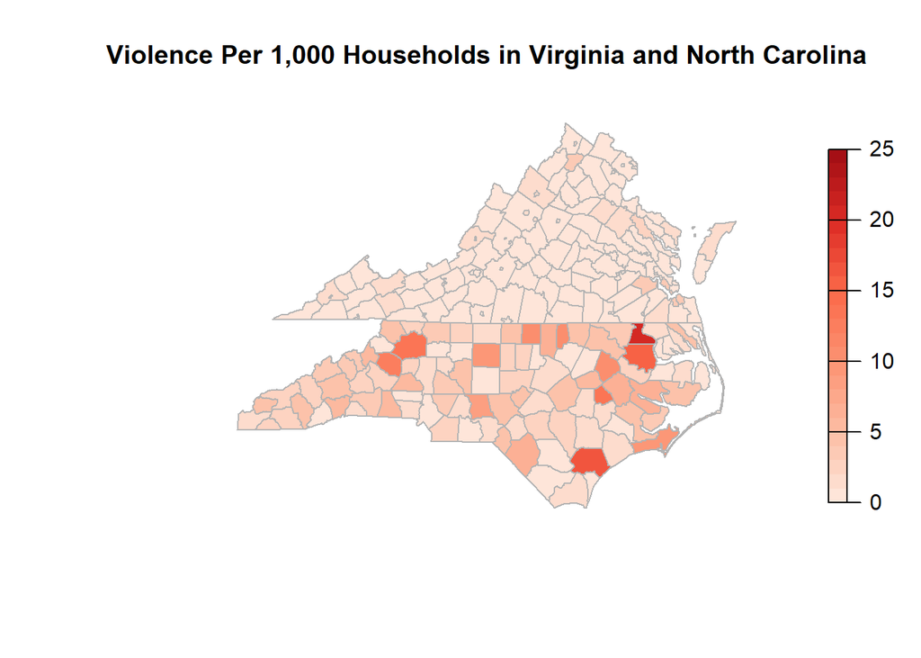

In the above figure, the top map represents Virginia and bottom map represents North Carolina. When we look at the domestic violance in the counties, it is seen that the violance rates are higher in some regions in North Carolina. In general, the domestic violance is low among both counties.

Another useful insight could be liquor sales in both county. It is one of the most important variables since it is directly reflection of the alcohol consumption. The visualision of map for two counties is below:

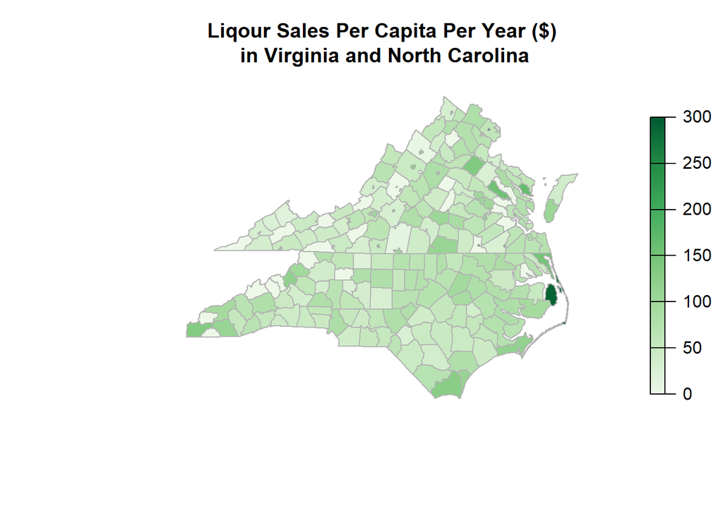

We can see that highest sales have occured in East North Carolina. Moreover, for both states the liqour sales are generally low (mostly between 0-150$).

Second analysis is about demographic structure of the states. Urban population is a good indicator to give an idea about consumer densities. Since urban areas has more people living in it, sales are directly affected from it. Therefore, next graph shows the density of urban population in both states.

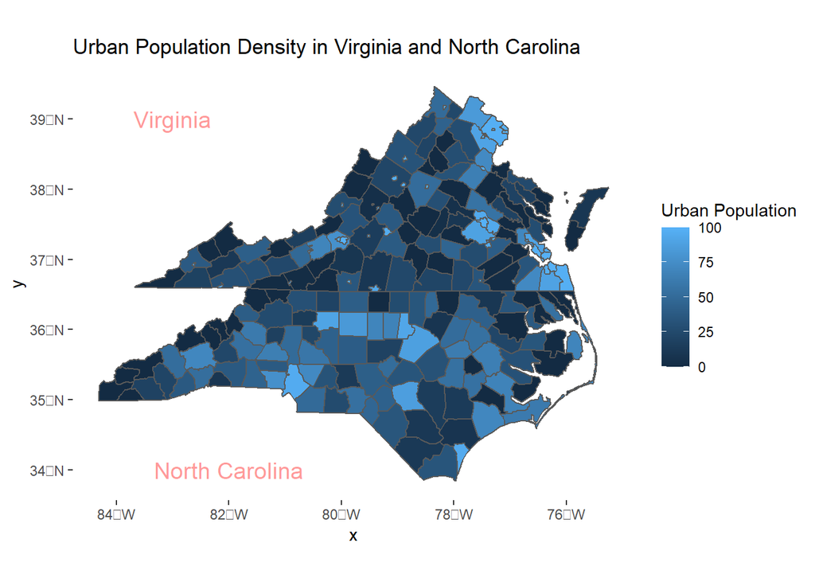

It is shown in the map that the urbanisation rate of the Virginia is less than North Carolina. Since urban population is more in North Carolina, the alcohol sales can be affected from this, but we will see the situation in our analysis.

Another useful insight about the data set, mapping the another crime related indicator in the data set. In below map, we visualized DUI arrests per 1,000 people who are older than 18. Driving under the influence (DUI) is the offense of driving, operating, or being in control of a vehicle while impaired by alcohol or other drugs (including recreational drugs and those prescribed by physicians), to a level that renders the driver incapable of operating a motor vehicle safely (Source:Wikipedia). It is useful to see DUI arrests in order to have an idea about domestic violance.

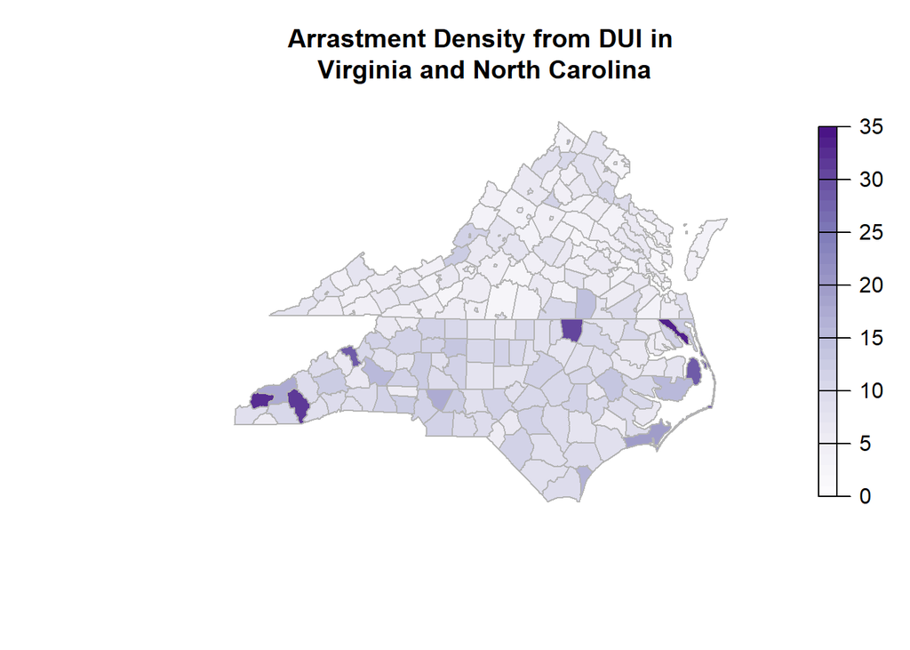

From the map, it is seen that the DUI arrests are higher in North Carolina.

After getting main insight about important indicators, the next section introduce modelling of the data set. We will first construct a traditonal OLS model as benchmark. After OLS, acording to diagnostic test results, we will construct spatial models.

## 2. MODELING

Before jumping construction of models, first we need a spatial weight matrix for spatial models in the following part of the model.

### 2.1. Preparing Spatial Weights Matrix

Structure of the neighborhood is key factor while constructing a spatial model. In our analysis, we tried to create few neighborhood matrix which are contiguity matrix and k nearest neighbors (knn) matrix. We also checked neighbours for symmetry.

The result of the contiguity matrix is provided below:

```
## Characteristics of weights list object:
## Neighbour list object:
## Number of regions: 234
## Number of nonzero links: 1132
## Percentage nonzero weights: 2.067353
## Average number of links: 4.837607
##
## Weights style: W
## Weights constants summary:
##     n    nn  S0       S1       S2
## W 234 54756 234 116.5866 999.1077
```

The plot of neighbours is provided below:

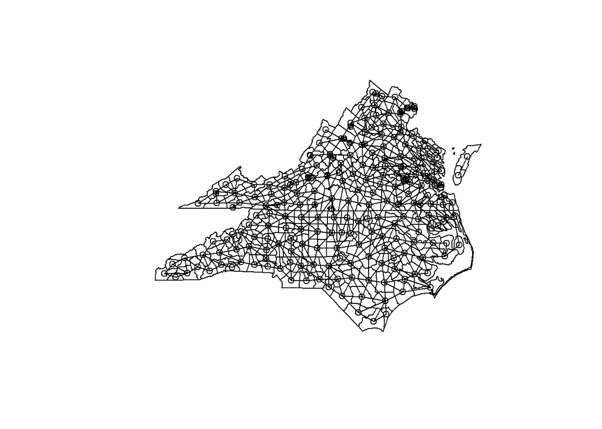

Secondly, we created spatial weights matrix with k nearest neighbours. The number of closest neighbours is selected 3. The result map is provided below:

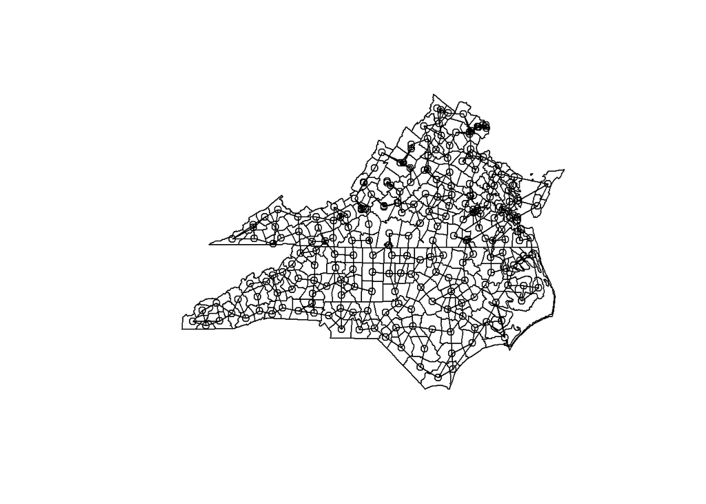

We can check whether the neighbourhood matrix is symmetric. The symmetry test shows that, the matrix is not symmetric since the test result gives FALSE. We can turn it to syymetric matrix as below:

```r
# print(is.symmetric.nb(spa.knn.nb)) --> checking symmetry of matrix

# creating symettric knn neighbours matrix

spa.sym.knn.nb<-make.sym.nb(spa.knn.nb)
# print(is.symmetric.nb(spa.sym.knn.nb))
```

We can also save symmetric matrix as **listw** class. The results below shows that average number of links is nearly 3.6.

```
## Characteristics of weights list object:
## Neighbour list object:
## Number of regions: 234
## Number of nonzero links: 842
## Percentage nonzero weights: 1.537731
## Average number of links: 3.598291
##
## Weights style: W
## Weights constants summary:
##     n    nn  S0       S1       S2
## W 234 54756 234 132.5111 948.3306
```

Lastly, we can calculate at what distance all units have at least one neighbour. At 0.7975231 km, all units have at least one neighbour. This neighborhood is concentrated in eastern Virginia.

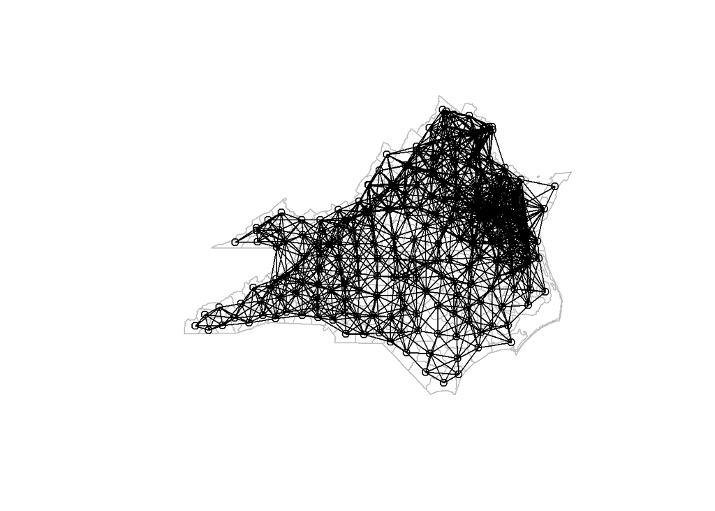

After calculating spatial weights matrix and showing neighbourhood, it is time to construct different models.

### 2.2. OLS

First step is constructing a non-spatial model with OLS. After model construction,we will test its residuals against spatial autocorrelation by Moran’s I test. Moran’s I is a measure of spatial autocorrelation–how related the values of a variable are based on the locations where they were measured.

The base model is constructed with variables that are thought to be important for domestic violance. The model is provided below:

```r
ols <- lm(FVPTHH02 ~ SALESPC + DUI1802 + SOMECOLLP + BKGRTOABC + BAPTISTSP + BKGRTOMIX + ENTRECP + UNEMPP + PCI + URBANP, data = spadata)
```

The output of the model is provided below:

```
##
## Call:
## lm(formula = FVPTHH02 ~ SALESPC + DUI1802 + SOMECOLLP + BKGRTOABC +
##     BAPTISTSP + BKGRTOMIX + ENTRECP + UNEMPP + PCI + URBANP,
##     data = spadata)
##
## Residuals:
##     Min      1Q  Median      3Q     Max
## -3.0446 -1.3871 -0.7337  0.3356 16.6940
##
## Coefficients:
##               Estimate Std. Error t value Pr(>|t|)
## (Intercept)  3.6467610  1.4069891   2.592   0.0102 *
## SALESPC     -0.0035135  0.0048322  -0.727   0.4679
## DUI1802      0.1599117  0.0379803   4.210  3.7e-05 ***
## SOMECOLLP    0.0333517  0.0621375   0.537   0.5920
## BKGRTOABC   -0.2235830  0.0886584  -2.522   0.0124 *
## BAPTISTSP    0.0444064  0.0201373   2.205   0.0285 *
## BKGRTOMIX   -0.0253304  0.0471577  -0.537   0.5917
## ENTRECP     -0.1745028  0.0809680  -2.155   0.0322 *
## UNEMPP       0.0757246  0.0701704   1.079   0.2817
## PCI         -0.0001097  0.0001031  -1.064   0.2883
## URBANP      -0.0154595  0.0079804  -1.937   0.0540 .
## ---
## Signif. codes:  0 '***' 0.001 '**' 0.01 '*' 0.05 '.' 0.1 ' ' 1
##
## Residual standard error: 2.749 on 223 degrees of freedom
## Multiple R-squared:  0.1722, Adjusted R-squared:  0.1351
## F-statistic: 4.639 on 10 and 223 DF,  p-value: 5.215e-06
```

From the result of the model, DUI1802, BKGRTOABC, BAPTISTSP, ENTRECP and URBANP (significant in 0.1 significance level) variables are seen as significant variables. This shows that educaiton, income and employement related indicators has no effect on the domestic violance. Moreover, liquor sales is insignificant in the model. It implies that alcohol consumption does not have an effect on violance.

Now, we will test our model residuals’ autocorrelation with Moran’s I test. In addition to Moran’s tests, Lagrange Multiplier test is also provided below. It is important to see the significance or misspecification of the constructed models.

#### 2.2.1. Moran Correlation Test

H0: No spatial correlation in the residuals

```r
# Moran's I test
ols_I <- lm.morantest(ols, cont.listw)
print(ols_I)
```

```
##
##  Global Moran I for regression residuals
##
## data:
## model: lm(formula = FVPTHH02 ~ SALESPC + DUI1802 + SOMECOLLP +
## BKGRTOABC + BAPTISTSP + BKGRTOMIX + ENTRECP + UNEMPP + PCI + URBANP,
## data = spadata)
## weights: cont.listw
##
## Moran I statistic standard deviate = 2.0484, p-value = 0.02026
## alternative hypothesis: greater
## sample estimates:
## Observed Moran I      Expectation         Variance
##      0.075142310     -0.016622322      0.002006893
```

Moran’s I statistic is significant (p < 0.05) Moran’s Statistic is ~0.075 which means that there is a significant evidence that positive spatial correlation exists between the residuals. So, we should use a spatial model.

#### 2.2.2. Lagrange Multiplier Test

```r
#Lagrange Multiplier Test

ols_LM <- lm.LMtests(ols, cont.listw, test = "all")
print(ols_LM)
```

```
##
##  Lagrange multiplier diagnostics for spatial dependence
##
## data:
## model: lm(formula = FVPTHH02 ~ SALESPC + DUI1802 + SOMECOLLP +
## BKGRTOABC + BAPTISTSP + BKGRTOMIX + ENTRECP + UNEMPP + PCI + URBANP,
## data = spadata)
## weights: cont.listw
##
## LMerr = 2.6519, df = 1, p-value = 0.1034
##
##
##  Lagrange multiplier diagnostics for spatial dependence
##
## data:
## model: lm(formula = FVPTHH02 ~ SALESPC + DUI1802 + SOMECOLLP +
## BKGRTOABC + BAPTISTSP + BKGRTOMIX + ENTRECP + UNEMPP + PCI + URBANP,
## data = spadata)
## weights: cont.listw
##
## LMlag = 6.2164, df = 1, p-value = 0.01266
##
##
##  Lagrange multiplier diagnostics for spatial dependence
##
## data:
## model: lm(formula = FVPTHH02 ~ SALESPC + DUI1802 + SOMECOLLP +
## BKGRTOABC + BAPTISTSP + BKGRTOMIX + ENTRECP + UNEMPP + PCI + URBANP,
## data = spadata)
## weights: cont.listw
##
## RLMerr = 4.065, df = 1, p-value = 0.04378
##
##
##  Lagrange multiplier diagnostics for spatial dependence
##
## data:
## model: lm(formula = FVPTHH02 ~ SALESPC + DUI1802 + SOMECOLLP +
## BKGRTOABC + BAPTISTSP + BKGRTOMIX + ENTRECP + UNEMPP + PCI + URBANP,
## data = spadata)
## weights: cont.listw
##
## RLMlag = 7.6295, df = 1, p-value = 0.005742
##
##
##  Lagrange multiplier diagnostics for spatial dependence
##
## data:
## model: lm(formula = FVPTHH02 ~ SALESPC + DUI1802 + SOMECOLLP +
## BKGRTOABC + BAPTISTSP + BKGRTOMIX + ENTRECP + UNEMPP + PCI + URBANP,
## data = spadata)
## weights: cont.listw
##
## SARMA = 10.281, df = 2, p-value = 0.005854
```

#### 2.2.3. Other Diagnostic Tests for OLS

##### 2.2.3.1. Breusch-Pagan Test for Heteroscedasticity

```r
bptest(ols) # heteroscedasticity (H1) /homoscedastic (H0)
```

```
##
##  studentized Breusch-Pagan test
##
## data:  ols
## BP = 19.878, df = 10, p-value = 0.03043
```

- p-value is 0.03 so we reject H0 homoscedasticity which means we have heteroscedasticity.

##### 2.2.3.2. Ramsey’s Test for Functional Form

H1: when non-linear variables (like powers of the variables) should be included then model is mis-specified

```r
resettest(ols, power=2, type="regressor")
```

```
##
##  RESET test
##
## data:  ols
## RESET = 2.032, df1 = 10, df2 = 213, p-value = 0.03152
```

##### 2.2.3.3. Moran Scatter Plot

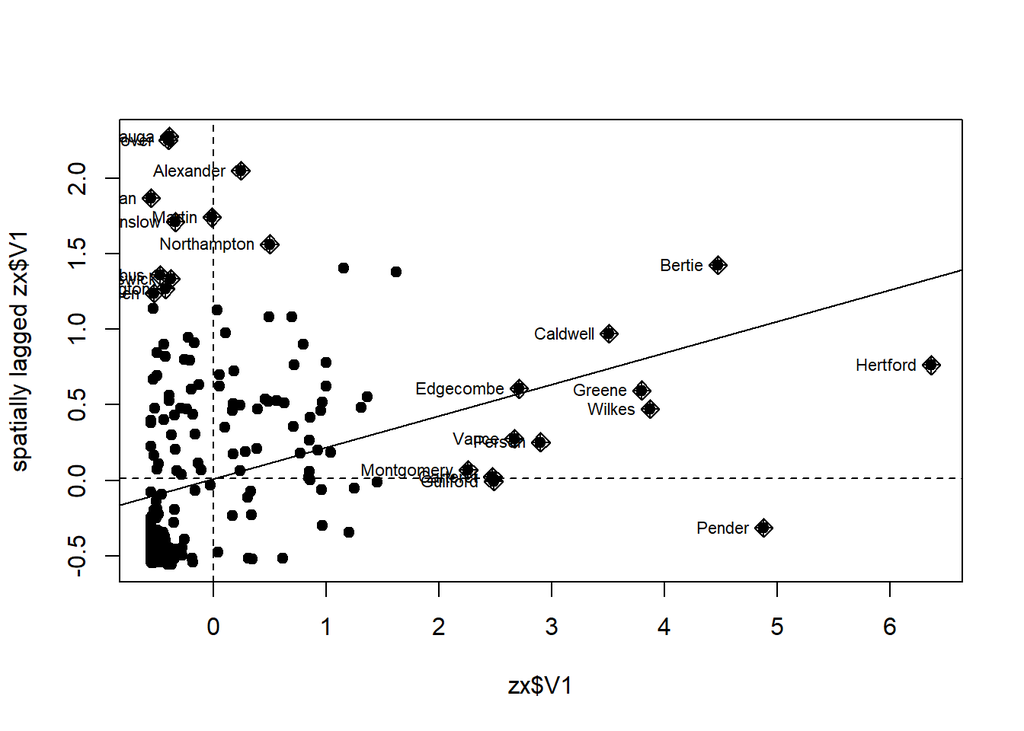

We can see on the Moran scatter plot how our dependent variable’s spatial correlation. We can also cluster negatives and positives next to each other and check how they correlate. In order to do that we took the residuals and cluster them and after that we used join count test.

```
##
##  Join count test under nonfree sampling
##
## data:  resid
## weights: cont.listw
##
## Std. deviate for negative = 2.1284, p-value = 0.01665
## alternative hypothesis: greater
## sample estimates:
## Same colour statistic           Expectation              Variance
##             60.299982             56.665236              2.916367
##
##
##  Join count test under nonfree sampling
##
## data:  resid
## weights: cont.listw
##
## Std. deviate for positive = 3.2694, p-value = 0.0005388
## alternative hypothesis: greater
## sample estimates:
## Same colour statistic           Expectation              Variance
##             14.785714             10.665236              1.588372
```

We can see from the results that both negative and positive residuals have positive spatial correlation. Which another indicator that we should continue with spatial model instead of OLS.

On the next plot we can see how the OLS residuals distribute on our map.

```
##    Min. 1st Qu.  Median    Mean 3rd Qu.    Max.
## -3.0446 -1.3871 -0.7337  0.0000  0.3356 16.6940
```

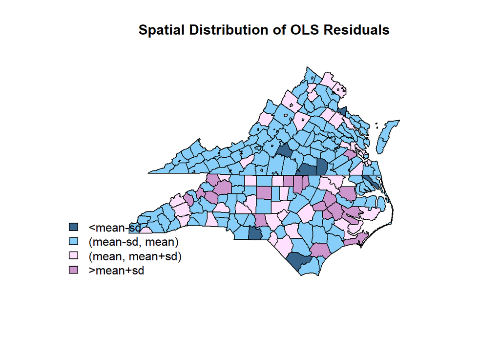

Based on Moran I test and Join Count Test we decided to use spatial models because according to both tests there is a significant evidence that there is spatial correlation between residuals.

### 2.3. SAR /SEM

GNS: Y= WY+Xβ+WX+u and u= Wu+e

rho spatial lag of dependent variable (impacts) beta theta spatial lag of explanotary variable lambda spatial lag of error term (in order to get random term which is epsilon)

We wanted to start with Monski model to see what we should expect from our model.

### 2.4. Monski Model

```
##
## Call:sacsarlm(formula = FVPTHH02 ~ SALESPC + DUI1802 + SOMECOLLP +
##     BKGRTOABC + BAPTISTSP + BKGRTOMIX + ENTRECP + UNEMPP + PCI +
##     URBANP, data = spadata, listw = cont.listw, type = "sacmixed",
##     method = "LU")
##
## Residuals:
##      Min       1Q   Median       3Q      Max
## -3.80724 -1.51767 -0.43462  0.58912 16.15443
##
## Type: sacmixed
## Coefficients: (numerical Hessian approximate standard errors)
##                  Estimate  Std. Error z value Pr(>|z|)
## (Intercept)    2.41422642  3.08663851  0.7822 0.434124
## SALESPC        0.00127866  0.00446953  0.2861 0.774814
## DUI1802        0.12501939  0.04193567  2.9812 0.002871
## SOMECOLLP     -0.08575990  0.07652366 -1.1207 0.262416
## BKGRTOABC     -0.10169763  0.09136867 -1.1130 0.265688
## BAPTISTSP      0.01289190  0.02478152  0.5202 0.602909
## BKGRTOMIX     -0.09117188  0.06365812 -1.4322 0.152083
## ENTRECP       -0.18288679  0.08417404 -2.1727 0.029801
## UNEMPP         0.04613386  0.06796677  0.6788 0.497283
## PCI            0.00011587  0.00014252  0.8130 0.416206
## URBANP        -0.01207744  0.00860208 -1.4040 0.160315
## lag.SALESPC   -0.00484075  0.01124977 -0.4303 0.666979
## lag.DUI1802   -0.00767180  0.06004111 -0.1278 0.898326
## lag.SOMECOLLP  0.06633228  0.11048262  0.6004 0.548249
## lag.BKGRTOABC -0.22390732  0.21695172 -1.0321 0.302044
## lag.BAPTISTSP  0.03342310  0.03711937  0.9004 0.367896
## lag.BKGRTOMIX  0.13203755  0.10138307  1.3024 0.192792
## lag.ENTRECP    0.06775593  0.15108131  0.4485 0.653812
## lag.UNEMPP     0.15479320  0.18179849  0.8515 0.394517
## lag.PCI       -0.00016075  0.00019327 -0.8317 0.405561
## lag.URBANP     0.01222741  0.01539683  0.7942 0.427108
##
## Rho: 0.26725
## Approximate (numerical Hessian) standard error: 0.24539
##     z-value: 1.0891, p-value: 0.27611
## Lambda: -0.1446
## Approximate (numerical Hessian) standard error: 0.30115
##     z-value: -0.48016, p-value: 0.63111
##
## LR test value: 17.902, p-value: 0.11871
##
## Log likelihood: -554.0976 for sacmixed model
## ML residual variance (sigma squared): 6.5368, (sigma: 2.5567)
## Number of observations: 234
## Number of parameters estimated: 24
## AIC: 1156.2, (AIC for lm: 1150.1)
```

DUI1802, ENTRECP significant while the rest are insignificant and if it comes to thetas all of them are insignificant. We can also see from the result that Rho and Lambda are insignificant as well and model’s AIC is 1156.2, which we are seeking for the smallest AIC for the best model.

```r
# SAC / SARAR model - includes spatial lag of Y, spatial error term
SAC_1<-sacsarlm(FVPTHH02 ~ SALESPC + DUI1802 + SOMECOLLP + BKGRTOABC + BAPTISTSP + BKGRTOMIX + ENTRECP + UNEMPP + PCI + URBANP, data = spadata, listw=cont.listw)
summary(SAC_1)
```

```
##
## Call:sacsarlm(formula = FVPTHH02 ~ SALESPC + DUI1802 + SOMECOLLP +
##     BKGRTOABC + BAPTISTSP + BKGRTOMIX + ENTRECP + UNEMPP + PCI +
##     URBANP, data = spadata, listw = cont.listw)
##
## Residuals:
##      Min       1Q   Median       3Q      Max
## -3.36429 -1.42510 -0.54661  0.38884 16.10519
##
## Type: sac
## Coefficients: (asymptotic standard errors)
##                Estimate  Std. Error z value  Pr(>|z|)
## (Intercept)  2.0536e+00  1.2442e+00  1.6506 0.0988200
## SALESPC     -2.4107e-03  4.4265e-03 -0.5446 0.5860202
## DUI1802      1.2524e-01  3.5213e-02  3.5567 0.0003755
## SOMECOLLP    1.4964e-03  5.0894e-02  0.0294 0.9765440
## BKGRTOABC   -1.7581e-01  8.0106e-02 -2.1947 0.0281839
## BAPTISTSP    3.0434e-02  1.6724e-02  1.8198 0.0687915
## BKGRTOMIX   -1.7480e-02  3.7372e-02 -0.4677 0.6399833
## ENTRECP     -1.4970e-01  7.1656e-02 -2.0892 0.0366889
## UNEMPP       7.9210e-02  6.2999e-02  1.2573 0.2086362
## PCI         -3.1847e-05  8.4347e-05 -0.3776 0.7057524
## URBANP      -9.3766e-03  6.8392e-03 -1.3710 0.1703741
##
## Rho: 0.45565
## Asymptotic standard error: 0.13527
##     z-value: 3.3683, p-value: 0.00075625
## Lambda: -0.37713
## Asymptotic standard error: 0.18907
##     z-value: -1.9947, p-value: 0.046073
##
## LR test value: 9.2565, p-value: 0.0097719
##
## Log likelihood: -558.4201 for sac model
## ML residual variance (sigma squared): 6.3928, (sigma: 2.5284)
## Number of observations: 234
## Number of parameters estimated: 14
## AIC: 1144.8, (AIC for lm: 1150.1)
```

As we can see in SAC / SARAR model model thetas disappeared from result as planned. DUI1802, BKGRTOABC, BAPTISTSP ENTRECP are significant. And we can see this time that both rho and lambda are significant. Rho: 0.45565 Lambda: -0.37713 And AIC: 1144.8 which is smaller than AIC’s of Monski model and also smaller than AIC for lm. It means our model is getting better and for our dataset this model perform very well. We will continue to check the rest models to see if we can improve our results.

```r
SDEM_1<-errorsarlm(FVPTHH02 ~ SALESPC + DUI1802 + SOMECOLLP + BKGRTOABC + BAPTISTSP + BKGRTOMIX + ENTRECP + UNEMPP + PCI + URBANP, data = spadata, listw=cont.listw, etype="emixed") # with spatial lags of X
summary(SDEM_1)
```

```
##
## Call:errorsarlm(formula = FVPTHH02 ~ SALESPC + DUI1802 + SOMECOLLP +
##     BKGRTOABC + BAPTISTSP + BKGRTOMIX + ENTRECP + UNEMPP + PCI +
##     URBANP, data = spadata, listw = cont.listw, etype = "emixed")
##
## Residuals:
##      Min       1Q   Median       3Q      Max
## -3.75795 -1.48172 -0.46523  0.53740 16.20849
##
## Type: error
## Coefficients: (asymptotic standard errors)
##                  Estimate  Std. Error z value Pr(>|z|)
## (Intercept)    3.67807413  3.14138733  1.1708 0.241662
## SALESPC        0.00089763  0.00482713  0.1860 0.852481
## DUI1802        0.13261755  0.03948441  3.3587 0.000783
## SOMECOLLP     -0.07561711  0.07531979 -1.0039 0.315404
## BKGRTOABC     -0.12074949  0.08854831 -1.3637 0.172676
## BAPTISTSP      0.01449679  0.02417629  0.5996 0.548754
## BKGRTOMIX     -0.08006816  0.05988319 -1.3371 0.181199
## ENTRECP       -0.18801346  0.08264359 -2.2750 0.022906
## UNEMPP         0.05710916  0.06861179  0.8324 0.405210
## PCI            0.00010062  0.00013916  0.7230 0.469677
## URBANP        -0.01212876  0.00842882 -1.4390 0.150161
## lag.SALESPC   -0.00559119  0.01177019 -0.4750 0.634766
## lag.DUI1802    0.02221873  0.07438664  0.2987 0.765175
## lag.SOMECOLLP  0.06460579  0.11694765  0.5524 0.580651
## lag.BKGRTOABC -0.29143677  0.20982955 -1.3889 0.164857
## lag.BAPTISTSP  0.04773422  0.03558809  1.3413 0.179824
## lag.BKGRTOMIX  0.12225760  0.10388387  1.1769 0.239248
## lag.ENTRECP    0.02561429  0.15585545  0.1643 0.869458
## lag.UNEMPP     0.16213335  0.19580486  0.8280 0.407650
## lag.PCI       -0.00018808  0.00020015 -0.9397 0.347371
## lag.URBANP     0.01042038  0.01642674  0.6344 0.525850
##
## Lambda: 0.13879, LR test value: 2.039, p-value: 0.15331
## Approximate (numerical Hessian) standard error: 0.095515
##     z-value: 1.4531, p-value: 0.14621
## Wald statistic: 2.1114, p-value: 0.14621
##
## Log likelihood: -554.4008 for error model
## ML residual variance (sigma squared): 6.6617, (sigma: 2.581)
## Number of observations: 234
## Number of parameters estimated: 23
## AIC: 1154.8, (AIC for lm: 1154.8)
```

In this thetas came back and we omit rho this time. This model has AIC: 1154.8 which is bigger than SAC / SARAR Model which means it is worst than previous model. So we decided to move forward.

```r
SEM_1<-errorsarlm(FVPTHH02 ~ SALESPC + DUI1802 + SOMECOLLP + BKGRTOABC + BAPTISTSP + BKGRTOMIX + ENTRECP + UNEMPP + PCI + URBANP, data = spadata, listw=cont.listw) # no spat-lags of X
summary(SEM_1)
```

```
##
## Call:errorsarlm(formula = FVPTHH02 ~ SALESPC + DUI1802 + SOMECOLLP +
##     BKGRTOABC + BAPTISTSP + BKGRTOMIX + ENTRECP + UNEMPP + PCI +
##     URBANP, data = spadata, listw = cont.listw)
##
## Residuals:
##      Min       1Q   Median       3Q      Max
## -3.40143 -1.43397 -0.60096  0.33362 16.60005
##
## Type: error
## Coefficients: (asymptotic standard errors)
##                Estimate  Std. Error z value  Pr(>|z|)
## (Intercept)  3.6373e+00  1.4584e+00  2.4941   0.01263
## SALESPC     -2.4992e-03  4.6613e-03 -0.5362   0.59184
## DUI1802      1.5204e-01  3.7883e-02  4.0134 5.985e-05
## SOMECOLLP    1.4400e-02  6.3735e-02  0.2259   0.82126
## BKGRTOABC   -1.9304e-01  8.7821e-02 -2.1981   0.02794
## BAPTISTSP    3.8556e-02  2.0932e-02  1.8419   0.06549
## BKGRTOMIX   -3.4634e-02  4.8848e-02 -0.7090   0.47831
## ENTRECP     -1.6809e-01  7.9977e-02 -2.1017   0.03558
## UNEMPP       6.4540e-02  6.8266e-02  0.9454   0.34445
## PCI         -8.1018e-05  1.0768e-04 -0.7524   0.45183
## URBANP      -1.5407e-02  8.0127e-03 -1.9228   0.05451
##
## Lambda: 0.17275, LR test value: 3.0763, p-value: 0.079441
## Approximate (numerical Hessian) standard error: 0.097497
##     z-value: 1.7719, p-value: 0.076416
## Wald statistic: 3.1395, p-value: 0.076416
##
## Log likelihood: -561.5102 for error model
## ML residual variance (sigma squared): 7.0623, (sigma: 2.6575)
## Number of observations: 234
## Number of parameters estimated: 13
## AIC: 1149, (AIC for lm: 1150.1)
```

In SEM - spatial error model we eliminate both rho and theta and lambda is significant. And from results we can see that this model has AIC: 1149 which is bigger that SAC / SARAR Model’s AIC.

```r
SDM_1<-lagsarlm(FVPTHH02 ~ SALESPC + DUI1802 + SOMECOLLP + BKGRTOABC + BAPTISTSP + BKGRTOMIX + ENTRECP + UNEMPP + PCI + URBANP, data = spadata, listw=cont.listw, type="mixed") # with spatial lags of X
summary(SDM_1)
```

```
##
## Call:lagsarlm(formula = FVPTHH02 ~ SALESPC + DUI1802 + SOMECOLLP +
##     BKGRTOABC + BAPTISTSP + BKGRTOMIX + ENTRECP + UNEMPP + PCI +
##     URBANP, data = spadata, listw = cont.listw, type = "mixed")
##
## Residuals:
##      Min       1Q   Median       3Q      Max
## -3.80896 -1.49591 -0.45728  0.58310 16.21364
##
## Type: mixed
## Coefficients: (numerical Hessian approximate standard errors)
##                  Estimate  Std. Error z value Pr(>|z|)
## (Intercept)    3.00224161  2.98317360  1.0064 0.314227
## SALESPC        0.00113401  0.00532204  0.2131 0.831266
## DUI1802        0.12945115  0.03986029  3.2476 0.001164
## SOMECOLLP     -0.08156537  0.07728969 -1.0553 0.291279
## BKGRTOABC     -0.10983965  0.09181669 -1.1963 0.231582
## BAPTISTSP      0.01307984  0.02576608  0.5076 0.611707
## BKGRTOMIX     -0.08569821  0.06183108 -1.3860 0.165745
## ENTRECP       -0.18587744  0.08388335 -2.2159 0.026698
## UNEMPP         0.05174836  0.07008758  0.7383 0.460309
## PCI            0.00011027  0.00014349  0.7685 0.442202
## URBANP        -0.01213242  0.00861797 -1.4078 0.159189
## lag.SALESPC   -0.00526946  0.01156277 -0.4557 0.648587
## lag.DUI1802    0.00523086  0.06449631  0.0811 0.935360
## lag.SOMECOLLP  0.06578147  0.11937080  0.5511 0.581587
## lag.BKGRTOABC -0.25756515  0.20662729 -1.2465 0.212573
## lag.BAPTISTSP  0.04034100  0.03534332  1.1414 0.253702
## lag.BKGRTOMIX  0.12797545  0.10279790  1.2449 0.213160
## lag.ENTRECP    0.04812120  0.15462207  0.3112 0.755635
## lag.UNEMPP     0.15852199  0.18946766  0.8367 0.402778
## lag.PCI       -0.00017451  0.00020008 -0.8722 0.383099
## lag.URBANP     0.01154727  0.01600307  0.7216 0.470561
##
## Rho: 0.14645, LR test value: 2.477, p-value: 0.11552
## Approximate (numerical Hessian) standard error: 0.089293
##     z-value: 1.6401, p-value: 0.10099
## Wald statistic: 2.6899, p-value: 0.10099
##
## Log likelihood: -554.1818 for mixed model
## ML residual variance (sigma squared): 6.646, (sigma: 2.578)
## Number of observations: 234
## Number of parameters estimated: 23
## AIC: 1154.4, (AIC for lm: 1154.8)
```

SAR - spatial lag model normally includes spatial lag of Y only (with rho coefficient) but with option type=“mixed” we activated spatial lags of X (with theta coeff.) And AIC is 1154.4 which is bigger than SAC / SARAR Model.

```r
SAR_1<-lagsarlm(FVPTHH02 ~ SALESPC + DUI1802 + SOMECOLLP + BKGRTOABC + BAPTISTSP + BKGRTOMIX + ENTRECP + UNEMPP + PCI + URBANP, data = spadata, listw=cont.listw) # no spatial lags of X
summary(SAR_1)
```

```
##
## Call:lagsarlm(formula = FVPTHH02 ~ SALESPC + DUI1802 + SOMECOLLP +
##     BKGRTOABC + BAPTISTSP + BKGRTOMIX + ENTRECP + UNEMPP + PCI +
##     URBANP, data = spadata, listw = cont.listw)
##
## Residuals:
##      Min       1Q   Median       3Q      Max
## -3.57628 -1.40586 -0.56383  0.34646 16.44920
##
## Type: lag
## Coefficients: (numerical Hessian approximate standard errors)
##                Estimate  Std. Error z value  Pr(>|z|)
## (Intercept)  2.9473e+00  1.4020e+00  2.1022   0.03553
## SALESPC     -2.4479e-03  4.7309e-03 -0.5174   0.60486
## DUI1802      1.4682e-01  3.7263e-02  3.9400 8.148e-05
## SOMECOLLP    8.7926e-03  7.4924e-02  0.1174   0.90658
## BKGRTOABC   -1.8831e-01  8.6232e-02 -2.1837   0.02898
## BAPTISTSP    3.5253e-02  1.9682e-02  1.7912   0.07327
## BKGRTOMIX   -2.7774e-02  4.6031e-02 -0.6034   0.54627
## ENTRECP     -1.7010e-01  7.9085e-02 -2.1509   0.03148
## UNEMPP       7.2732e-02  6.7966e-02  1.0701   0.28456
## PCI         -5.9095e-05  1.2063e-04 -0.4899   0.62420
## URBANP      -1.3129e-02  7.9480e-03 -1.6519   0.09855
##
## Rho: 0.21051, LR test value: 6.1877, p-value: 0.012864
## Approximate (numerical Hessian) standard error: 0.083704
##     z-value: 2.515, p-value: 0.011904
## Wald statistic: 6.3251, p-value: 0.011904
##
## Log likelihood: -559.9545 for lag model
## ML residual variance (sigma squared): 6.9461, (sigma: 2.6355)
## Number of observations: 234
## Number of parameters estimated: 13
## AIC: 1145.9, (AIC for lm: 1150.1)
```

Same model without theta coefficants performed better with AIC 1145.9 as well but still it is slightly bigger than SAC / SARAR model’s AIC which is 1144.8.

```r
SLX_1<-lmSLX(FVPTHH02 ~ SALESPC + DUI1802 + SOMECOLLP + BKGRTOABC + BAPTISTSP + BKGRTOMIX + ENTRECP + UNEMPP + PCI + URBANP, data = spadata,
             listw=cont.listw)
summary(SLX_1)
```

```
##
## Call:
## lm(formula = formula(paste("y ~ ", paste(colnames(x)[-1], collapse = "+"))),
##     data = as.data.frame(x), weights = weights)
##
## Residuals:
##     Min      1Q  Median      3Q     Max
## -3.8603 -1.4802 -0.5304  0.6265 16.4322
##
## Coefficients:
##                 Estimate Std. Error t value Pr(>|t|)
## (Intercept)    3.089e+00  3.100e+00   0.996  0.32021
## SALESPC        6.798e-04  5.047e-03   0.135  0.89297
## DUI1802        1.289e-01  4.220e-02   3.053  0.00255 **
## SOMECOLLP     -6.891e-02  8.126e-02  -0.848  0.39737
## BKGRTOABC     -1.176e-01  9.438e-02  -1.246  0.21428
## BAPTISTSP      1.696e-02  2.616e-02   0.648  0.51759
## BKGRTOMIX     -8.146e-02  6.513e-02  -1.251  0.21240
## ENTRECP       -1.848e-01  8.816e-02  -2.097  0.03721 *
## UNEMPP         5.673e-02  7.252e-02   0.782  0.43486
## PCI            9.123e-05  1.505e-04   0.606  0.54514
## URBANP        -1.226e-02  9.039e-03  -1.356  0.17657
## lag.SALESPC   -4.579e-03  1.218e-02  -0.376  0.70723
## lag.DUI1802    4.609e-02  7.646e-02   0.603  0.54728
## lag.SOMECOLLP  6.332e-02  1.219e-01   0.520  0.60395
## lag.BKGRTOABC -2.709e-01  2.171e-01  -1.248  0.21345
## lag.BAPTISTSP  4.249e-02  3.683e-02   1.154  0.24998
## lag.BKGRTOMIX  1.146e-01  1.090e-01   1.052  0.29404
## lag.ENTRECP    1.769e-02  1.594e-01   0.111  0.91177
## lag.UNEMPP     1.913e-01  1.985e-01   0.964  0.33631
## lag.PCI       -1.717e-04  2.081e-04  -0.825  0.41014
## lag.URBANP     9.600e-03  1.685e-02   0.570  0.56957
## ---
## Signif. codes:  0 '***' 0.001 '**' 0.01 '*' 0.05 '.' 0.1 ' ' 1
##
## Residual standard error: 2.723 on 213 degrees of freedom
## Multiple R-squared:  0.2244, Adjusted R-squared:  0.1516
## F-statistic: 3.082 on 20 and 213 DF,  p-value: 2.564e-05
```

In here we checked an ‘lm’ model augmented with the spatially lagged RHS variables which didn’t perform well.

After seeing all model results we would like to choose our final model as SAC / SARAR model but in order to do so we need to do proper Likelihood ratio test first to see if it is indeed would be a good choice.

### 2.5. Diagnostic Tests

```r
LR.sarlm(GNS_1, SAC_1)
```

```
##
##  Likelihood ratio for spatial linear models
##
## data:
## Likelihood ratio = 8.6451, df = 10, p-value = 0.5661
## sample estimates:
## Log likelihood of GNS_1 Log likelihood of SAC_1
##               -554.0976               -558.4201
```

```r
LR.sarlm(SAC_1, SAR_1)
```

```
##
##  Likelihood ratio for spatial linear models
##
## data:
## Likelihood ratio = 3.0688, df = 1, p-value = 0.07981
## sample estimates:
## Log likelihood of SAC_1 Log likelihood of SAR_1
##               -558.4201               -559.9545
```

```r
LR.sarlm(SAC_1, SEM_1)
```

```
##
##  Likelihood ratio for spatial linear models
##
## data:
## Likelihood ratio = 6.1802, df = 1, p-value = 0.01292
## sample estimates:
## Log likelihood of SAC_1 Log likelihood of SEM_1
##               -558.4201               -561.5102
```

In the first test we compare Manski model with SAC / SARAR model and we cannot reject H0 with p-value 0.5661 which means narrower model is better and in this case SAC / SAR model is narrower.

In the second test we compare SAC / SAR model with SARAR (Spatial Lag Model) and our p-value is 0.07981 and we think that we can reject H0 since it is below 0.1 significant level which means wider model is better and in this case SAC / SAR model is wider.

In the last test we compare SAC / SARAR model with SEM (Spatial Error Model) and we reject H0 with p-value 0.01292 which means wider model is better and in this case SAC / SAR model is wider.

### 2.6 Final Model

SAC / SARAR model - includes spatial lag of Y, spatial error term

```r
# SAC / SARAR model - includes spatial lag of Y, spatial error term
SAC_1<-sacsarlm(FVPTHH02 ~ SALESPC + DUI1802 + SOMECOLLP + BKGRTOABC + BAPTISTSP + BKGRTOMIX + ENTRECP + UNEMPP + PCI + URBANP, data = spadata, listw=cont.listw)
summary(SAC_1)
```

```
##
## Call:sacsarlm(formula = FVPTHH02 ~ SALESPC + DUI1802 + SOMECOLLP +
##     BKGRTOABC + BAPTISTSP + BKGRTOMIX + ENTRECP + UNEMPP + PCI +
##     URBANP, data = spadata, listw = cont.listw)
##
## Residuals:
##      Min       1Q   Median       3Q      Max
## -3.36429 -1.42510 -0.54661  0.38884 16.10519
##
## Type: sac
## Coefficients: (asymptotic standard errors)
##                Estimate  Std. Error z value  Pr(>|z|)
## (Intercept)  2.0536e+00  1.2442e+00  1.6506 0.0988200
## SALESPC     -2.4107e-03  4.4265e-03 -0.5446 0.5860202
## DUI1802      1.2524e-01  3.5213e-02  3.5567 0.0003755
## SOMECOLLP    1.4964e-03  5.0894e-02  0.0294 0.9765440
## BKGRTOABC   -1.7581e-01  8.0106e-02 -2.1947 0.0281839
## BAPTISTSP    3.0434e-02  1.6724e-02  1.8198 0.0687915
## BKGRTOMIX   -1.7480e-02  3.7372e-02 -0.4677 0.6399833
## ENTRECP     -1.4970e-01  7.1656e-02 -2.0892 0.0366889
## UNEMPP       7.9210e-02  6.2999e-02  1.2573 0.2086362
## PCI         -3.1847e-05  8.4347e-05 -0.3776 0.7057524
## URBANP      -9.3766e-03  6.8392e-03 -1.3710 0.1703741
##
## Rho: 0.45565
## Asymptotic standard error: 0.13527
##     z-value: 3.3683, p-value: 0.00075625
## Lambda: -0.37713
## Asymptotic standard error: 0.18907
##     z-value: -1.9947, p-value: 0.046073
##
## LR test value: 9.2565, p-value: 0.0097719
##
## Log likelihood: -558.4201 for sac model
## ML residual variance (sigma squared): 6.3928, (sigma: 2.5284)
## Number of observations: 234
## Number of parameters estimated: 14
## AIC: 1144.8, (AIC for lm: 1150.1)
```

As we can see in SAC / SARAR model model thetas disappeared from result as planned. DUI1802, BKGRTOABC, BAPTISTSP and ENTRECP are significant. And we can see this time that both rho and lambda are significant. Rho: 0.45565 Lambda: -0.37713 And AIC: 1144.8 which is smaller than AIC’s of Monski model and also smaller than AIC for lm. It means our model is getting better and for our dataset this model perform very well.

## 3. CONCLUSION

In this project, we tried to find the model to answer our research question that is how alcohol restrictions affect the offense related problems. First, we investigated the data set visually. After that, we started to build model model with a non-spatial one. First model was OLS. Moran’s test for the OLS model showed that there is spatial effects of the residuals and spatial models should be developed. After that, we started to build different spatial models. We built Monski Model in the beginning and then SEM,SAR,SAC,SAR,SARAR models and tried to reach best model with highest significant variables and lowest AIC values. In the final stage, the best model is obtained with SAC / SARAR including spatial lag of Y, spatial error term. The main intepratation from this model output is that, domestic violance is not affected by alcohol consumption or alcohol sales. Therefore, we verified the previous study.